# 3rdDownSubset

Julian U-C

2024-09-20

This is a subset of all the 3rd downs from the NFL season, for now it’s just the Carolina Panthers 2023 season. Going to try all the methods, why not?

### Data manipulation

I need to add a column for conversion success, that will be our response. This is simple, is the yards gained on 3rd down > distance to 1st down? I’ll also add a column qtrWindow, which will tell us if the 3rd down was at the end, middle, or start of the quarter. Just using time would add too many parameters. I’m not sure how R uses time, but we just need the minutes and can give window 0-5, 5-10, and 10-15 for end, middle, start, respectively. Also change quarter to a factor!

```r
thirdDown <- third %>%
  mutate(success = NA, qtrWindow = NA) %>%
  mutate(success = ifelse(is.na(success), yardsGained > dist )) %>%
  separate(time, into = c("minutes", "seconds"),
           sep = ":", fill = "right") %>%
  mutate(minutes = as.numeric(minutes),
         seconds = as.numeric(seconds),
         quarter = as.factor(quarter)) %>%
  mutate(qtrWindow = case_when(
    minutes < 5 ~ "end",
    minutes >= 5 & minutes < 10 ~ "middle",
    minutes >= 10 ~ "start",
    TRUE ~ NA_character_)) %>%
  mutate(qtrWindow = factor(qtrWindow, levels = c("start", "middle", "end")))

# make sure everything looks okay
str(thirdDown)
```

```
## 'data.frame':    284 obs. of  14 variables:
##  $ gameDate   : chr  "9/10/2023" "9/10/2023" "9/10/2023" "9/10/2023" ...
##  $ gameNum    : int  1 1 1 1 1 1 1 1 1 1 ...
##  $ team       : chr  "Panthers" "Panthers" "Panthers" "Panthers" ...
##  $ quarter    : Factor w/ 4 levels "1","2","3","4": 4 4 4 4 4 4 4 3 3 3 ...
##  $ minutes    : num  13 11 11 7 4 1 0 11 6 2 ...
##  $ seconds    : num  9 42 42 25 34 23 28 31 48 58 ...
##  $ down       : chr  "3rd" "3rd" "3rd" "3rd" ...
##  $ dist       : int  1 10 5 8 10 5 15 10 6 9 ...
##  $ fieldSide  : chr  "OWN" "OWN" "OWN" "OWN" ...
##  $ yardLine   : int  34 36 41 3 25 38 34 33 40 47 ...
##  $ yardsGained: int  2 -7 0 0 -12 9 0 8 0 0 ...
##  $ outCome    : chr  "(13:09) (NO HUDDLE, SHOTGUN) 6-M.SERS RIGHT GUARD TO CAR 36 FOR 2 YARDS (90-D.ONYEMATA, 44-T.ERSEN)." "(11:42) (SHOTGUN) 9-B.YOUNG SACKED AT CAR 29 FOR -7 YARDS (SACK SPLIT BY 44-T.ERSEN  97-G.JARRETT)." "(11:42) (SHOTGUN) PENALTY ON CAR-79-I.EKWONU, FALSE START, 5 YARDS, EN…
##  $ success    : logi  TRUE FALSE FALSE FALSE FALSE TRUE ...
##  $ qtrWindow  : Factor w/ 3 levels "start","middle",..: 1 1 1 2 3 3 3 1 2 3 ...
```

```r
# I want to save this
#write.csv(thirdDown, file = "thirdDownR.csv", row.names = FALSE)
```

*We have some parameters we can ignore when we are modeling:* time, minutes, seconds were only used to create qtrWindow factor, which is our stand in for time. yardsGained also doesn’t matter since it happened after the fact, it does not influence the 3rd down it occurred in (or so I think!). gameDate = gameNum, again IDK how to manage time in R (no pun intended). outcome I may be able to use at a later stage! down… I mean we know what down it is brother. I’m going to remove these to have a cleaner dataframe.

**Basic scatter plot of the data**

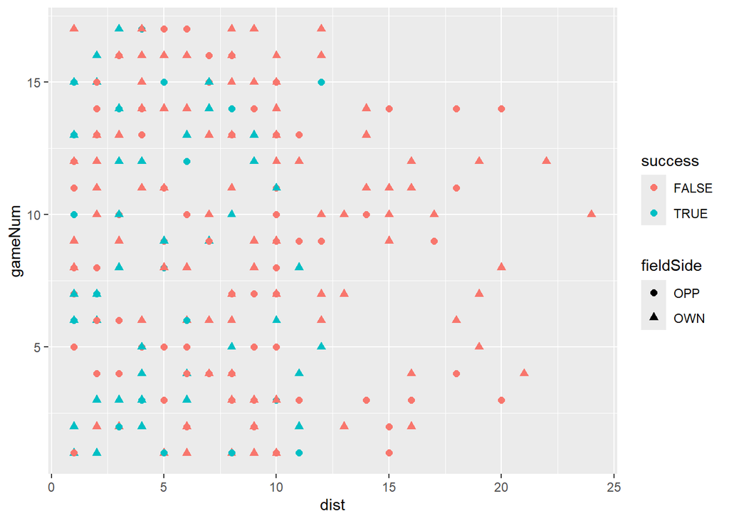

```r
# plot the data, how does it look
# can also use attach() function so you don't have to call the data each time

# Game number vs. conversion distance
ggplot(data = thirdDown, aes(x = dist,
                             y = gameNum,
                             colour = success,
                             shape = fieldSide)) +
  geom_point(size = 2)
```

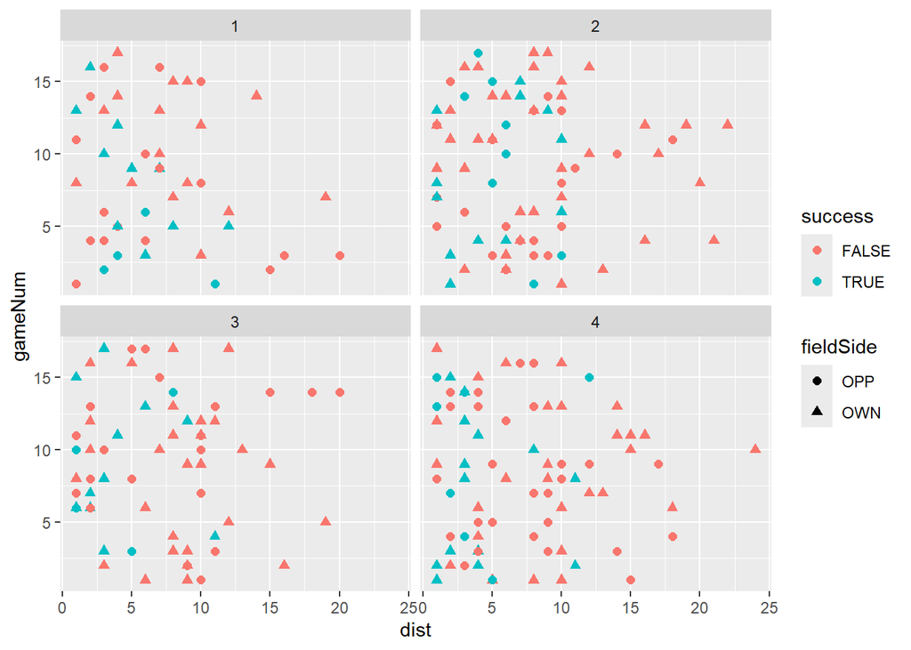

```r
# Let's look at conversions per quarter
ggplot(data = thirdDown, aes(x = dist,
                             y = gameNum,
                             colour = success,
                             shape = fieldSide)) +
  geom_point(size = 2) +
  facet_wrap(~ quarter)
```

**Quick summary statistics**

```r
summary(thirdDown)
```

```
##     gameNum       quarter      dist         fieldSide            yardLine
##  Min.   : 1.000   1:49    Min.   : 1.000   Length:284         Min.   : 0.00
##  1st Qu.: 4.000   2:85    1st Qu.: 3.000   Class :character   1st Qu.:22.00
##  Median : 9.000   3:67    Median : 6.500   Mode  :character   Median :31.00
##  Mean   : 8.792   4:83    Mean   : 7.116                      Mean   :30.08
##  3rd Qu.:13.000           3rd Qu.:10.000                      3rd Qu.:40.00
##  Max.   :17.000           Max.   :24.000                      Max.   :49.00
##   success         qtrWindow
##  Mode :logical   start : 94
##  FALSE:206       middle: 82
##  TRUE :78        end   :108
##
##
##
```

*Just from a superficial look at the data:*

More third downs occurred in the 2nd (85) and 4th (83) quarters

- maybe more likely to get to 4th down and kick a field goal to go into half/OT/win?

Mean 3.5 yards gained per 3rd down

- would be interesting to see how that varies by quarter?

### Linear model

Assumptions of linear model: response and predictors are linear? additive assumption (effects of changes in X<sub>j</sub> on Y is independent of the other predictors). Homoscedasticity (constant variance). Usually assumes a continuous response, so not recommended for my data.

Assessing fit: adjusted R<sup>2</sup>

Will need to have some dummy variables for quarter and qtrWindow. Let’s start with the full model and work back.

```r
# full model
lmFull <- lm(success ~ ., data = thirdDown)

summary(lmFull)
```

```
##
## Call:
## lm(formula = success ~ ., data = thirdDown)
##
## Residuals:
##     Min      1Q  Median      3Q     Max
## -0.5789 -0.3003 -0.1585  0.4530  0.9213
##
## Coefficients:
##                  Estimate Std. Error t value Pr(>|t|)
## (Intercept)      0.372418   0.114500   3.253  0.00129 **
## gameNum         -0.007092   0.005281  -1.343  0.18045
## quarter2         0.002174   0.076744   0.028  0.97742
## quarter3        -0.058759   0.079744  -0.737  0.46185
## quarter4        -0.015130   0.076163  -0.199  0.84269
## dist            -0.029056   0.005190  -5.599 5.25e-08 ***
## fieldSideOWN     0.110023   0.052320   2.103  0.03639 *
## yardLine         0.004930   0.002001   2.463  0.01438 *
## qtrWindowmiddle -0.020688   0.065213  -0.317  0.75131
## qtrWindowend    -0.049495   0.060578  -0.817  0.41461
## ---
## Signif. codes:  0 '***' 0.001 '**' 0.01 '*' 0.05 '.' 0.1 ' ' 1
##
## Residual standard error: 0.421 on 274 degrees of freedom
## Multiple R-squared:  0.1417, Adjusted R-squared:  0.1135
## F-statistic: 5.024 on 9 and 274 DF,  p-value: 2.802e-06
```

Oh shit man, Adjusted R<sup>2</sup> of 0.1135, think it’s save to say linear model ain’t it! Only parameters that appear significant are distance, field side, and yard line. That makes sense to me.

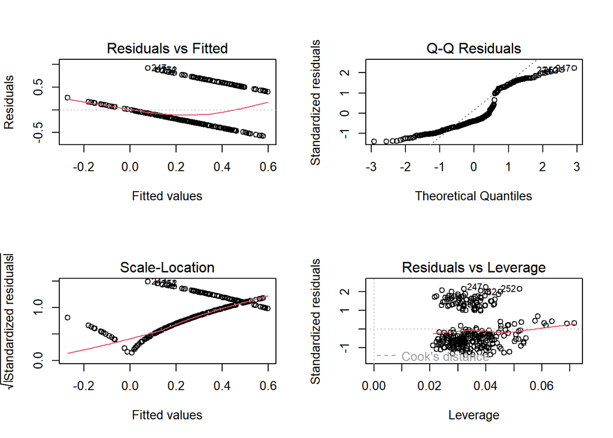

```r
par(mfrow = c(2, 2))
plot(lmFull)
```

**Linear model is cooked** Residuals vs Fitted plots suggests heteroscedasticity (unequal variances of residuals) also parallel because my response is binary (success/fail), S-shaped QQ plot = not normal distribution. Was coo lto practice though.

### Logistic model

This one I have more faith in.

```r
glmFull <- glm(success ~ ., data = thirdDown, family = binomial)
summary(glmFull)
```

```
##
## Call:
## glm(formula = success ~ ., family = binomial, data = thirdDown)
##
## Coefficients:
##                 Estimate Std. Error z value Pr(>|z|)
## (Intercept)     -0.41584    0.66783  -0.623   0.5335
## gameNum         -0.04200    0.03041  -1.381   0.1672
## quarter2         0.01296    0.42930   0.030   0.9759
## quarter3        -0.36406    0.45754  -0.796   0.4262
## quarter4        -0.09777    0.42936  -0.228   0.8199
## dist            -0.20070    0.03974  -5.050 4.42e-07 ***
## fieldSideOWN     0.61835    0.31023   1.993   0.0462 *
## yardLine         0.02884    0.01230   2.345   0.0190 *
## qtrWindowmiddle -0.05684    0.36931  -0.154   0.8777
## qtrWindowend    -0.30214    0.35104  -0.861   0.3894
## ---
## Signif. codes:  0 '***' 0.001 '**' 0.01 '*' 0.05 '.' 0.1 ' ' 1
##
## (Dispersion parameter for binomial family taken to be 1)
##
##     Null deviance: 333.89  on 283  degrees of freedom
## Residual deviance: 287.30  on 274  degrees of freedom
## AIC: 307.3
##
## Number of Fisher Scoring iterations: 5
```

OK, similar to linear model only a few variables are significant (distance, field side, and yard line)

```r
# Generate probabilities of success according to glm
glmProb <- predict(glmFull, type = "response")
#contrasts(success)

# quick summary of the probabilities
# average 27% conversion success prob., highest was 70%
summary(glmProb)
```

```
##     Min.  1st Qu.   Median     Mean  3rd Qu.     Max.
## 0.009189 0.125255 0.238347 0.274648 0.412602 0.698978
```

Next step is to calculate classification error rate, to do so we need to get the 2024 season to test (should be similar since Panthers still suck!)